# LAB_2

Bartosz Łabiszak, Zakład Ekologii Roślin i Ochrony Środowiska

# Genomika Populacyjna: Wykrywanie Doboru Naturalnego - dane genomowe

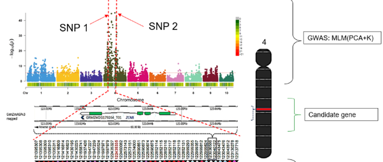

**1. Opis danych do wykonania ćwiczeń**

Celem głównym dzisiejszych zajęć będzie wykrywania SNPs różnicujących populacje, które związane są z ich **dywergencją i potencjalnie** są przyczyną lokalnej adaptacji **do odmiennych warunków życia** w szerokim gradiencie środowiskowym. Na dzisiejszych zajęciach pracować będziemy z danymi genomowymi (nadal jest to raczej niewielki zestaw danych, nadający się na ćwiczenia) – dane te pochodzą z genotypowania RADseq **717** osobników z **24** lokalizacji, podzielonych na 2 regiony (**północ, południe**) i łącznie **3699 SNPs**.

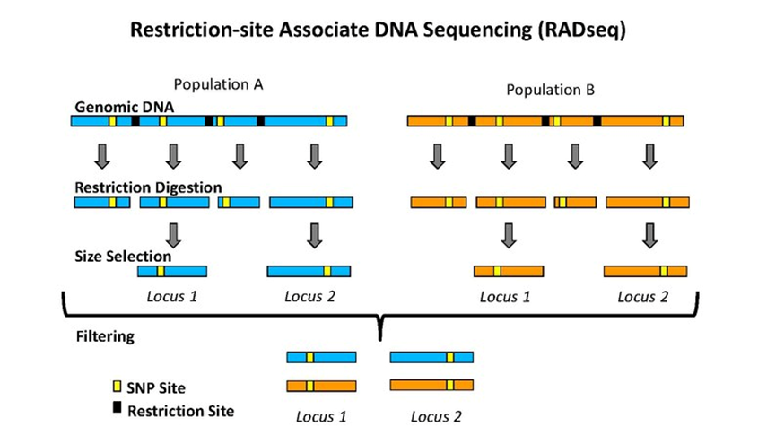

Dane z którymi będziemy pracować są **w formacie VCF** (variant calling files). Plik VCF zawiera informacje o zidentyfikowanych zmianach w sekwencji DNA, takie jak zmiany pojedynczych nukleotydów (SNP), w odniesieniu **do sekwencji referencyjnej.** Nagłówek zawiera informacje o źródle danych i definicje metadanych, takie jak informacje o sekwencji referencyjnej i sposobie kodowania wariantów. Sekcja wariantów zawiera szczegółowe informacje o każdym wariancie genetycznym, w tym położenie na sekwencji referencyjnej, typ zmiany, informacje o jakości sekwencjonowania i liczbę próbek, w których znaleziono dany wariant.

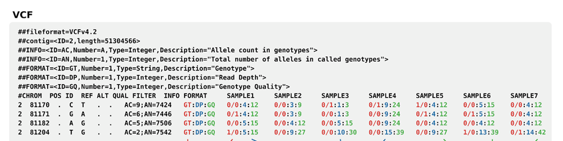

Więcej o pliku vcf znajdziesz tu: https://samtools.github.io/hts-specs/VCFv4.2.pdf

W naszych ćwiczeniach pomijamy już istotne kroki, związane z kontrolą jakości odczytów, przyrównaniem do genomu referencyjnego, które same w sobie wymagają skomplikowanych procedur bioinformatycznych.

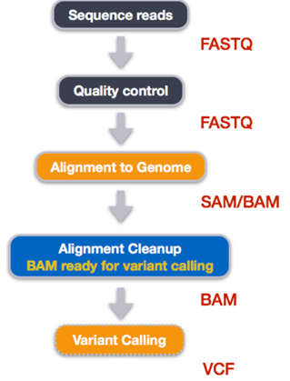

## Wymagane pakiety i wczytanie danych

Najpierw ładujemy wymagane pakiety R i wczytujemy dane genomiczne. Korzystamy z bibliotek **vcfR** do wczytywania i przetwarzania danych VCF, Do wykrywania outlierów związanych z adaptacją stosujemy **pcadapt** oraz **OutFLANK**, natomiast pakiet **qvalue** umożliwi korektę p-wartości na wielokrotne testowanie (FDR).Wykorzystamy również **ggVennDiagram** do prezentacji wyników analizy w formie diagramów Venna oraz zbiór pakietów **tidyverse** do ogólnej manipulacji, analizy i wizualizacji danych. Upewnij się, że wszystkie te pakiety są zainstalowane.

```r
#Install and load required packages (installation lines are commented out assuming packages installed)

# install.packages("BiocManager")
# For Bioconductor package installation if needed

# install.packages("remotes")
# install.packages(c("vcfR", "pcadapt", "qvalue", "ggplot2"))
# BiocManager::install("qvalue")
# remotes::install_github("whitlock/OutFLANK")
# Install OutFLANK from GitHub`
# Load libraries
```

```r
# Load necessary libraries
packages <- c("vcfR", "pcadapt", "qvalue", "OutFLANK","ggVennDiagram",  "ggplot2", "pegas")

lapply(packages, require, character.only = TRUE)
```

## Szukanie outlierów - metoda pcadapt

**Funkcja pcadapt** wykonuje dwa zadania. Po pierwsze, wykonuje analizę PCA na zeskalowanej i znormalizowanej macierzy genotypów. Drugi etap polega na obliczeniu statystyk testowych i wartości p opartych na korelacjach między SNP-ami a pierwszymi K składowymi głównymi (PC). Większość SNP neutralnych powinna mieć wkład do nowych PC (PC loadings) **bliskie 0**. Za pomocą dystansu Mahalanobisa oceniana jest odległość PC loadings dla każdego SNP od rozmieszczenia neutralnego. Rozkład dystansów Mahalanobisa jest aproksymowany przez rozkład chi kwadrat **χ2** o liczbie stopni swobody równej ilość głównych składowych (PC) - co pozwala na uzyskanie **p value**

```r
# Zapisujemy ścieżkę do danych w pliku vcf i metadanych do osobnych obiektów w R:

vcf.path <- "XXX.vcf" # zmień na prawidłową ścieżkę
meta.path <- "YYY.csv" # zmień na prawidłową ścieżkę


# Wczytanie danych przez pcadapt
# pcadapt wczytuje dane bezpośrendio z formatu VCF.

XXX <- read.pcadapt(vcf.path,type=c("vcf")) # nadaj odpowiednią nazwę obiektowi

# Teraz wczytajmy metadane.
meta <- read.csv(X) # zmień na obiekt ze ścieżką do csv

# wybór głównych składowych PC w anzalizie pcadapt

XXX <- pcadapt(input = …,K= …)
# uzupełnij argument input (wczytane z vcf dane genotypowe)
# argument K to liczba PC składowych głównych opisujących „neutralną” strukturę genetyczną populacji K >20
```

By sprawdzić ile K należy wybrać, użyjemy metody „**scree plot**”. “Scree plot” wyświetla w malejącej kolejności procent wyjaśnionej wariancji przez każdą główną składową (PC). Optymalna wartość PC to taka, po której następuje “wypłaszczenie”

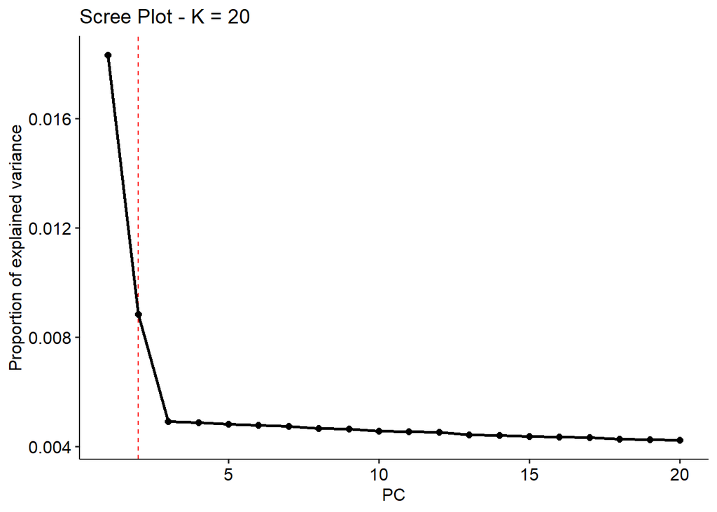

*Ryc: Optymalna liczba głównych składowych (PC) wybrana metodą screeplot*

Sprawdźmy PCA dla optymalnej liczby glównych składowych. Uzyj odpowiedniej kolumny z ramki danych **meta** - do przyporządkowania każdego osobnika do jednej grup (N vs S)

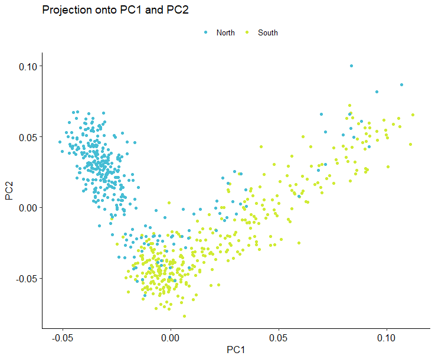

```r
plot(XXX, option = "scores", pop = …, i = ..., j = ..., col = c("COL1", "COL2"))

# XXX - wynik pcadapt, pop - przynależność do grupy z ramki meta, i, j = wybrane główne składowe
# col = wybrane kolory
```

*Ryc: PCA dla 2 składowych, osobniki oznaczone kolorem zgodnie z pochodzeniem.*

Zauważ, że grupy Północna i Południową, są rozdzielone na PCA **ale nie jest to pełny rozdział**. Sprawdźmy, które spośród ponad 3000 SNP odpowiadają za zauważoną zróżnicowanie na wykresie PCA. W drugim kroku obliczymy wkład każdego SNP (PC loadings) do naszych głównych składowych. Ponieważ nasze założenie to takie, że SNP outlierowe wpływają mocno na kształtowanie struktury w PCA, **ich wpływ na nowe składowe będzie wyraźny**.

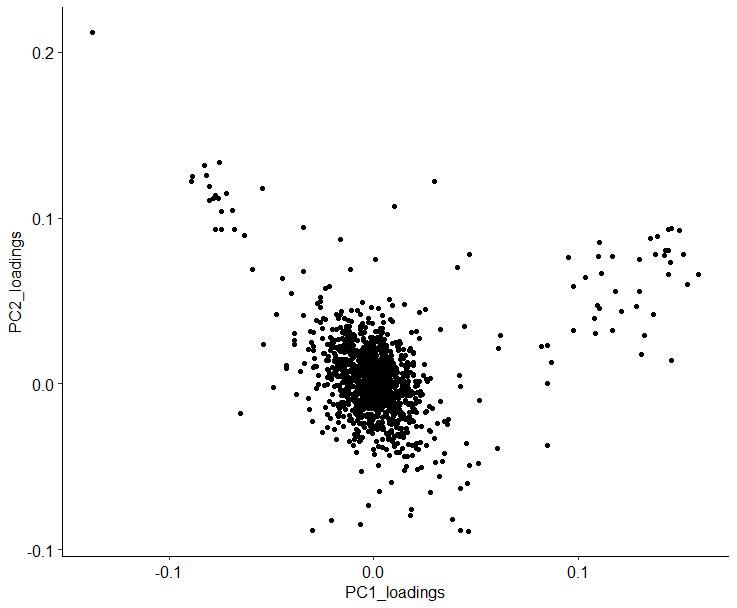

*Ryc: Wykres PC laodings dla główych składowych*

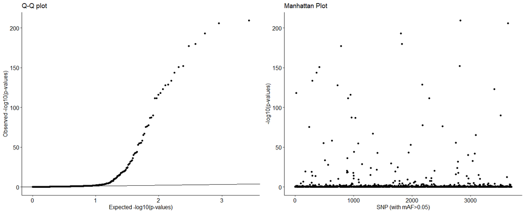

```r
# wykonaj analizę pcadapt dla optymalnej liczby K znalezionej na screeplot

XXX <- pcadapt(input = XXX,K= ...)
# uzupełnij argument input (wczytane z vcf dane genotypowe)
# K = optymalna wartość głównych składowych

# sprawdź podsumowanie dla obiektu wynikowego funkcji pcadapt
summary(XXX) # obiekt wynikowy pcadapt

# wykres pca loadings mówi nam o obecności outliers sprawdźmy kilka innych wykresów

plot(XXX, option="manhattan") # wartości p value przestawione jako -log(10)
plot(XXX, option="qqplot") # qq plot porównujący obserwowane i spodziewane p value
plot(XXX, option = "stat.distribution")
```

Innymi słowy, FDR jest sposobem **na korygowanie wartości p** w celu uwzględnienia faktu, że podczas testowania jednocześnie wielu hipotez, istnieje prawdopodobieństwo otrzymania fałszywie dodatnich wyników. Kontrola FDR działa poprzez uporządkowanie wartości p uzyskanych z wielu testów, a następnie obliczenie dystrybucji kumulatywnej wartości p. Następnie wybierane jest progi wartości zwane **q-wartościami**, które kontrolują oczekiwaną proporcję fałszywie dodatnich wyników wśród wszystkich istotnych wyników.

Dla danej wartości **α**, SNP z q-wartością mniejszą niż α zostaną uznane za outliery z oczekiwanym FDR tj – gdy **α = 0.1 – 10% z odnalezionych przez nas SNP może być wynikiem fałszywie dodatnim.**

```r
# Sprawdzenie które SNP można uznać za outlierowe w metodzie pcadapt

#kontrola FDR - z pakietem qvalue

qval <- qvalue(XXX$pvalues)$qvalues
# jako XXX wstaw odpowiendni obiekt z wynikami pcadapt

outliers_pcadapt <- which(qval< ZZZ) # wstaw odpowiednią wartość dla FDR
length(outliers_pcadapt) # ile outliers?
outliers_pcadapt # które SNP to outliers?
```

**Zadanie 1**– Wykonaj analizę pcadapt dla naszego zestawu danych. Za pomocą testu screeplot ustal optymalną liczbę K głównych składowych, wykonaj wykres PCA z podziałem na grupy North i South dla tych wartości K. Przedstaw na wykresie Manhattan loci potencjalnie pod działaniem doboru. Zaraportuj liczbę loci outlierowych przy poziomie FDR = 0.1. Wklej do raportu wszystkie wykresy.

## Szukanie outlierów - metoda FST outliers

Druga metodą poszukiwania sygnałów doboru jest oparta **skanie genomowym** z wykorzystaniem metody **Fst**. Fst to miara różnic genetycznych między populacjami. Korzystając z Fst w celu testowania sygnałów selekcji, próbujemy odnaleźć SNP o zróżnicowaniu większym niż średnia całogenomowa. Testy te będą tym czulsze, im więcej SNP użyjemy by oszacować średnie Fst na poziomie genomu.

Na początek użyjemy biblioteki R **vcfR**, aby załadować plik VCF i wyodrębnić z tego pliku jedynie dane genotypowe. Pliki VCF zawiarają wiele informacji – my potrzebujemy jedynie matrycę genotypów.

```r
# wczytanie pliku vcf
data <- read.vcfR(vcf.path)

# podgląd pola meta i fix
data@meta
data@fix
data@gt[1:3,1:5]
# wyciągamy jedynie informacje o genotypach
geno <- extract.gt(data)
dim(geno)
head(geno[,1:10])
```

```
## [1] "##fileformat=VCFv4.2"
## [2] "##fileDate=20161214"
## [3] "##source=\"Stacks v1.44\""
## [4] "##INFO=<ID=NS,Number=1,Type=Integer,Description=\"Number of Samples With Data\">"
## [5] "##INFO=<ID=AF,Number=.,Type=Float,Description=\"Allele Frequency\">"
## [6] "##FORMAT=<ID=GT,Number=1,Type=String,Description=\"Genotype\">"
## [7] "##FORMAT=<ID=DP,Number=1,Type=Integer,Description=\"Read Depth\">"
## [8] "##FORMAT=<ID=AD,Number=1,Type=Integer,Description=\"Allele Depth\">"
## [9] "##FORMAT=<ID=GL,Number=.,Type=Float,Description=\"Genotype Likelihood\">"
```

```
##      CHROM                         POS    ID       REF ALT QUAL FILTER
## [1,] "gi|762007364|gb|KN898073.1|" "4062" "7_11"   "A" "T" NA   "PASS"
## [2,] "gi|762007371|gb|KN898066.1|" "992"  "12_31"  "G" "A" NA   "PASS"
## [3,] "gi|762007371|gb|KN898066.1|" "1027" "10_7"   "G" "A" NA   "PASS"
## [4,] "gi|762007371|gb|KN898066.1|" "1038" "10_18"  "A" "G" NA   "PASS"
## [5,] "gi|762007371|gb|KN898066.1|" "1052" "10_32"  "G" "T" NA   "PASS"
## [6,] "gi|762007529|gb|KN897908.1|" "3132" "101_21" "A" "T" NA   "PASS"
##      INFO
## [1,] "NS=627;AF=0.069"
## [2,] "NS=646;AF=0.192"
## [3,] "NS=663;AF=0.019"
## [4,] "NS=659;AF=0.068"
## [5,] "NS=663;AF=0.012"
## [6,] "NS=652;AF=0.031"
```

```
##      FORMAT        CRA_1756                     CRA_1757
## [1,] "GT:DP:AD:GL" "0/0:112:112,0:-155.26,.,."  "./.:0:.,.:.,.,."
## [2,] "GT:DP:AD:GL" "0/1:472:317,155:.,272.54,." "1/1:141:0,141:.,.,-159.84"
## [3,] "GT:DP:AD:GL" "0/0:234:234,0:-324.39,.,."  "0/0:80:80,0:-110.9,.,."
##      CRA_1758                 CRA_1759
## [1,] "0/0:31:31,0:-42.98,.,." "0/0:17:17,0:-26.34,.,."
## [2,] "./.:0:.,.:.,.,."        "0/0:35:35,0:-48.52,.,."
## [3,] "./.:0:.,.:.,.,."        "0/0:12:12,0:-16.64,.,."
```

Nasza matryca genotypów jest w układzie – **Loci x Osobniki.** Dodatkowo nasze SNP zakodowane są jako zmienna tekstowa – np. „1/0”.

```r
# I -  utwórz kopię obiektu geno - tak, by móc ją modyfikować nie zmieniając oryginalnego oniektu geno
# II - zamień tekst "0/0" na 0, "1/0" lub "0/1" na 1 i "1/1" na 2 NA zamień na 9
# zmień typ danych na numeric
```

**Zajrzyj jeśli utknąłeś**

```r
G <- geno

G[geno %in% c("0/0")] <- 0
G[geno  %in% c("0/1", "1/0")] <- 1
G[geno %in% c("1/1")] <- 2
G[is.na(G)] <- 9
class(G) <- "numeric"
tG <- t(G)
```

Upewnij się, że nasze dane wyglądają tak:

```
##          7_11 12_31 10_7 10_18 10_32 101_21 106_23 106_55 119_62 128_5 159_58
## CRA_1756    0     1    0     0     0      0      0      0      0     0      0
## CRA_1757    9     2    0     0     0      0      0      0      0     0      0
## CRA_1758    0     9    9     9     9      0      9      9      0     0      0
## CRA_1759    0     0    0     0     0      9      0      0      0     0      0
## CRA_1760    0     0    0     0     0      0      0      1      0     0      0
##          159_56 159_47 159_29 159_25 192_44 194_44 214_60 214_38 238_35
## CRA_1756      0      0      0      1      1      0      9      9      0
## CRA_1757      0      0      0      0      0      0      0      0      0
## CRA_1758      0      0      0      0      0      0      0      0      0
## CRA_1759      0      0      0      0      0      0      0      1      9
## CRA_1760      0      0      0      0      0      0      0      0      0
```

Obliczenie odpowiedniej macierzy Fst jest możliwe przy użyciu funkcji **MakeDiploidFSTMat()** z pakietu OutFLANK. Funkcja ta wymaga od nas 3 argumentów: 1. SNPmat - Matrycy genotypów w odpowiednim formacie; 2. locusNames – wektor z nazwami naszych markerów; 3. popNames – wektor z nazwami populacji, dla każdego osobnika.

Matryca genotypów jest przygotowana – sprawdźmy zatem co z **nazwami loci i nazwami populacji**.

```r
loci_names <- …
# użyj numerycznego oznaczenia loci od 1 do ilość SNP
# lub wyciągnij odpowiednią kolumnę ze slotu fix pliku vcf -zawierającą nazwę SNP
head(loci_names)
pop_names <- … # wykorzystaj informację z ramki danych meta
pop_names
```

Obliczenie FST dla każdego SNP - główna część analizy OUTflank

```r
fst <- MakeDiploidFSTMat(SNPmat = …, locusNames = …, popNames = …) # użyj matrycy SNP, nazw loci i populacji
head(fst)
View(fst)
```

Nasza matryca zawiera wartości **He** – heterozygotycznośc danego locus, Fst dla danego locus oraz statystyki pośrednie użyte do obliczenia Fst bez korekty uwzględniającej wielkość próby – **FstNoCorr** – to na podstawie tej wartości wykonywany jest test **Chi – kwadrat**, który jest podstawą do znalezienia loci outlierowch. Założeniem testu outlierów OUTflank jest to, że loci outlierowe mają wysokie FST - ale co jest punktem odcięcia? Rozkład FST dla loci neutralnych powinien być przyblżony do rozkładu Chi- kwadrat - w neutralnie ewolujących populacjach spodziewamy się pewnej niewielkiej frakcji SNP o wysokim FST (dziłanie dryfu). Jeśli jest ich więcej niż zakładamy - najpewniej działa na nie dobór.

```
## Calculating FSTs, may take a few minutes...
```

```
##   LocusName         He          FST            T1         T2   FSTNoCorr
## 1         1 0.12694028  0.006724554  4.272689e-04 0.06353862 0.025780061
## 2         2 0.31094479 -0.004705401 -7.320462e-04 0.15557573 0.016009620
## 3         3 0.03705128 -0.004309565 -7.988266e-05 0.01853613 0.013644425
## 4         4 0.12611095 -0.009930720 -6.263863e-04 0.06307562 0.007801241
## 5         5 0.02387711 -0.001175959 -1.404907e-05 0.01194690 0.016793896
## 6         6 0.05973395  0.039228888  1.174403e-03 0.02993719 0.055734705
##       T1NoCorr   T2NoCorr meanAlleleFreq
## 1 0.0016380489 0.06353937      0.9318910
## 2 0.0024907359 0.15557745      0.8074534
## 3 0.0002529172 0.01853630      0.9811178
## 4 0.0004920729 0.06307624      0.9323708
## 5 0.0002006369 0.01194702      0.9879154
## 6 0.0016685574 0.02993749      0.9691834
```

Sprawdźmy rozkład częstości FST i jego zgodność z rozkładem Chi-kwadrat:

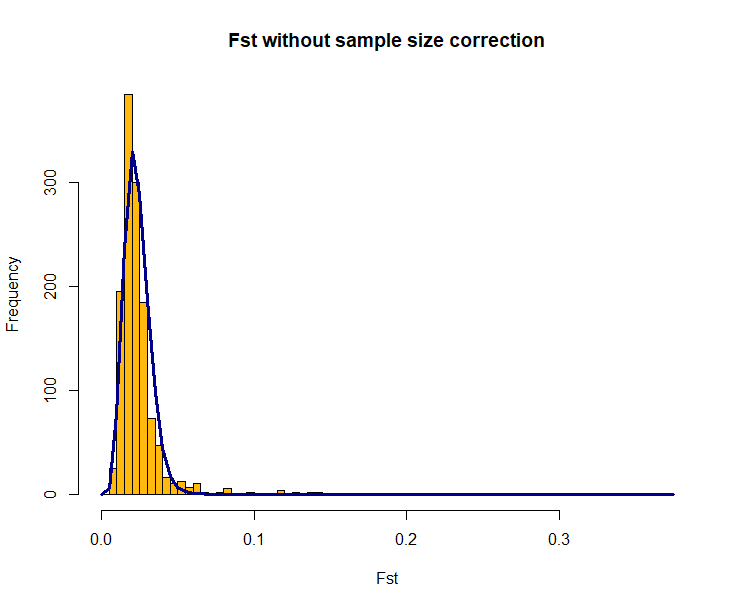

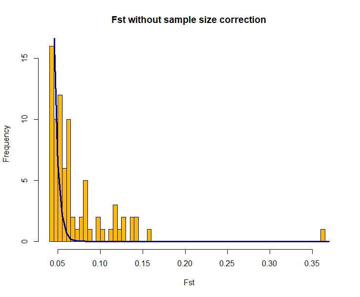

```r
# główna funkcja outflank
OF <- OutFLANK(fst,LeftTrimFraction=0.05,RightTrimFraction=0.06,
               Hmin=0.1,NumberOfSamples= ... ,qthreshold= ...)
# uzupełnij qtreshold - FDR analogiczny jak w pcadapt
# NumberOfSamples - liczba populacji
OutFLANKResultsPlotter(OF,withOutliers=T,
                       NoCorr=T,Hmin=0.1,binwidth=0.005,
                       Zoom=F,RightZoomFraction=0.05,titletext=NULL)

OutFLANKResultsPlotter(OF,withOutliers=T,
                       NoCorr=T,Hmin=0.1,binwidth=0.005,
                       Zoom=T,RightZoomFraction=0.05,titletext=NULL)
```

Średnie zróżnicowanie populacji jest niewielkie, o czym świadczą też niskie wartości Fst dla wielu loci, ale widać niektóre loci, które mocno różnicują nasze populacje. Żółte słupki to histogram wartości FST. Niebieska linia to dopasowanie rozkładu chi-kwadrat do danych. Na pierwszym wykresie ciężko to stwierdzić, ale drugi wykres pokazuje nam potencjalne SNP o **Fst wyższym niż przewiduje rozkład chi-kwadrat**. Aby znaleźć te SNP-y, pytamy, które są statystycznie istotnymi outlierami.

Ostatnim krokiem jest sprawdzenie które SNP zostały oznaczone jako outliery przez OutFlank i ich wizualizacja na wykresie Manhatan plot.

```r
outliers <- OF$results$OutlierFlag==TRUE
sum(outliers) # ile outlierów
table(outliers)

outlier_OF <- which(outliers == TRUE)
outlier_OF_names <- OF$results$LocusName[outlier_OF]

# wykres Manhattan

# wykonaj wykres Manhattan - pvalues vs kolejność SNP - pamiętaj, o -log 10 dla pvalue
plot(OF$results$XXX, OF$results$XXX, pch = 20, col = "grey")
points(OF$results$XXX[outliers],OF$results$XXX[outliers], pch=21, col="red")

# wykonaj wykres Manhattan - FST vs kolejność SNP
plot(OF$results$XXX, OF$results$XXX, pch = 20, col = "grey")
points(OF$results$XXX[outliers],OF$results$XXX[outliers], pch=21, col="red")
```

**Zajrzyj jeśli utknąłeś**

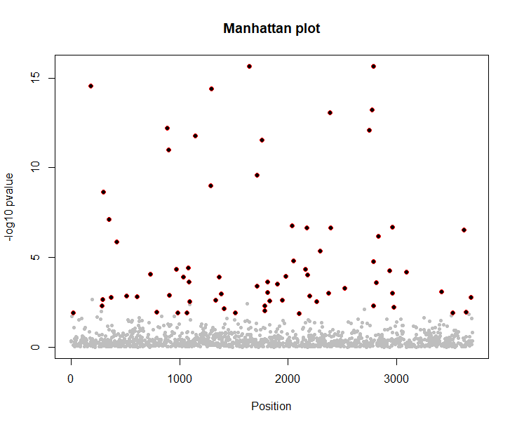

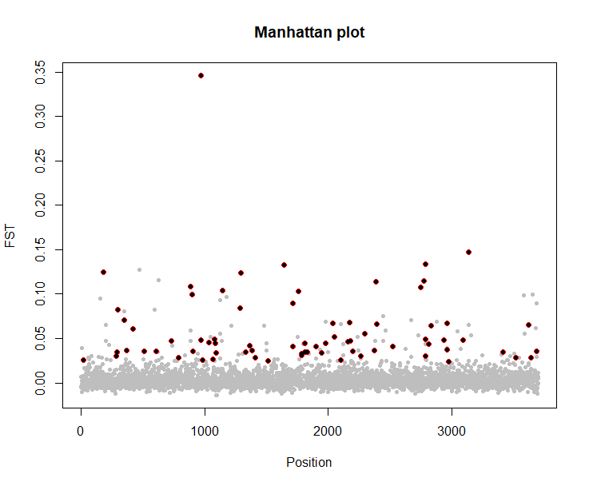

```r
plot(OF$results$indexOrder, -log10(OF$results$pvalues), pch=20, col="grey", xlab="Position",ylab="-log10 pvalue", main = "Manhattan plot")
points(OF$results$indexOrder[outliers],-log10(OF$results$pvalues[outliers]), pch=21, col="red")
points(OF$results$indexOrder[outliers],-log10(OF$results$pvalues[outliers]), pch=20, col="black")

plot(OF$results$indexOrder, OF$results$FST, pch=20, col="grey", xlab="Position",ylab="FST", main = "Manhattan plot")
points(OF$results$indexOrder[outliers],OF$results$FST[outliers], pch=21, col="red")
points(OF$results$indexOrder[outliers],OF$results$FST[outliers], pch=20, col="black")
```

**Zadanie 2**– Wykonaj analizę OutFLANK dla naszego zestawu danych. Wykonaj histogram częstości FST vs rozkład Chi-kwadrat. Zaraportuj liczbę loci outlierowych przy poziomie FDR = 0.1. Przedstaw na wykresie Manhattan loci potencjalnie pod działaniem doboru. Wklej do raportu wszystkie wykresy.

Ponieważ każda z metod generuje wyniki fałszywie dodatnie (nawet kontrolując poziom FDR nie jesteśmy w stanie ich wyeliminować) - rozsądnym podejściem będzie wskazanie jako potencjalnie o znaczaniu adaptatywnym tych SNP, które są wspólne dla dwóch metod. Porównajmy teraz ile SNP zostało wskazanych przez każdą z metod i jaka część wspólna tych SNP została wskazana przez obie?

```r
outlier_OF # które outliery wskazał outFLANK?
length(outlier_OF) #ile?
outliers_pcadapt # które outliery wskazał pcadapt?
length(outliers_pcadapt) # ile?

#część wspólna?
outliers_both <- XXX #znajdź SNP wspólne dla dwóch zestwów
length(outliers_both) #ile?
```

**Zajrzyj jeśli utknąłeś**

```r
outliers_both <- intersect(outlier_OF, outliers_pcadapt)
```

**Zadanie 3**– Korzystając z pakietu ggVennDiagram (help, manual, chatgtp) zobrazuj wykres Venn dla outlierów znalesionych dwoma metodami. Dołącz kod, który użyłeś do tej wizualizacji w raporcie.

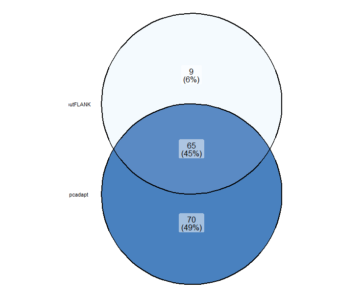

Sprawdzimy, czy metodą outFLANK znajdziemy więcej oulierów jeśli wybierzemy do naszych **testów 2 populacje ze skraju zasięgu**. Żeby je znaleźć potrzebujemy informacji z pliku **meta - które populacje reprezentują skraj zasięgu.**

**Zadanie 4**– Wykonaj analizę outFLANK wyłącznie dla dwóch populacji ze skraju zasięgu. Sprawdź czy liczba tak znalezionych outlierów będzie większa niż w pierwotnym wariancie. Wykonaj wykres Venn dla 3 zbiorów - outliery pcadapt, OF_full, OF_sub.

Pamiętajmy, że do znalezienia outlierów w outFlank w pierwszym kroku używamy **MakeDiploidFSTMat()** potrzebujemy matrycy genotypów **dla 2 populacji**, nie całego zestawu danych! Nasze genotypy są już w wymaganym formacie - musimy wyciagnąć odpowiednie osobniki.

```r
# posortuj tablę meta wg zmiennej LAT (szerokość geograficzna) - by znaleźć populacje ze skraju zasięgu
# (możesz też otworzyć oryginalny plik csv w Excelu lub użyć funkcji View)

subpops <- c("XXX","XXX") # subpops to nasze dwie skrajne populacje

subgen <- tG[meta$SITE%in%subpops,]
# kolejność osobników w pliku meta jest taka sama jak w pliku tG
#  wyciągamy tylko te genotypy, dla których wartość SITE jest taka sama, jak jedna z dwóch wartości w wektorze subpops
dim(subgen)
head(subgen[,1:10], n =30)
tail(subgen[,1:10], n =30)
submeta <- meta[meta$SITE%in%subpops,]

# Teraz pozostaje nam odtworzenie kroków MakeDiploidFSTMat()
# oraz OutFLANK() dla naszej matrycy Fst dla dwóch populacji.
```